# Bayesian and Frequentist Model Comparison - Don River

Dylan

2026-03-28

# Load Frequency and Bayesian Data

```r
library(tidyverse)

# Frequentist Outputs
frequentist_lambda <- read_rds(here::here("data", "model", "frequentist_model_fits", "lambda_hat.rds"))

frequentist_gpd <- read_rds(here::here("data", "model", "frequentist_model_fits", "gpd_fit.rds"))

# Bayesian Outputs
bayesian_pois <- read_rds(here::here("data", "model", "bayesian_model_fits", "poisson_fit.rds"))

bayesian_gpd <- read_rds(here::here("data", "model", "bayesian_model_fits", "gpd_fit.rds"))
```

# Create Table to Analyze

```r
# Extract Bayesian summaries
pois_summary <- bayesian_pois$summary()
gpd_summary  <- bayesian_gpd$summary()

# Keep only parameters
pois_params <- pois_summary %>%
  filter(variable == "lambda") %>%
  select(mean, sd, q5, q95)

gpd_params <- gpd_summary %>%
  filter(variable %in% c("sigma", "xi")) %>%
  select(variable, mean, sd, q5, q95)

# Frequentist values
freq_sigma <- frequentist_gpd$estimate["scale"]
freq_xi    <- frequentist_gpd$estimate["shape"]

# Combine into one table
comparison_table <- tibble(
  Parameter = c("lambda", "sigma", "xi"),

  Frequentist = c(
    frequentist_lambda,
    freq_sigma,
    freq_xi
  ),

  Bayesian_Mean = c(
    pois_params$mean,
    gpd_params$mean[gpd_params$variable == "sigma"],
    gpd_params$mean[gpd_params$variable == "xi"]
  ),

  Bayesian_SD = c(
    pois_params$sd,
    gpd_params$sd[gpd_params$variable == "sigma"],
    gpd_params$sd[gpd_params$variable == "xi"]
  ),

  CI_5 = c(
    pois_params$q5,
    gpd_params$q5[gpd_params$variable == "sigma"],
    gpd_params$q5[gpd_params$variable == "xi"]
  ),

  CI_95 = c(
    pois_params$q95,
    gpd_params$q95[gpd_params$variable == "sigma"],
    gpd_params$q95[gpd_params$variable == "xi"]
  )
)

comparison_table
```

```
## # A tibble: 3 × 6
##   Parameter Frequentist Bayesian_Mean Bayesian_SD   CI_5  CI_95
##   <chr>           <dbl>         <dbl>       <dbl>  <dbl>  <dbl>
## 1 lambda         1.59          1.60         0.215  1.27   1.98
## 2 sigma         12.4          13.0          2.54   9.14  17.3
## 3 xi             0.0758        0.0973       0.144 -0.115  0.358
```

The comparison table summarizes the alignment between frequentist point estimates and Bayesian posterior summaries for each model parameter.

Across all parameters (λ, σ, ξ), the Bayesian posterior means are consistent with the frequentist estimates, indicating that the likelihood has been correctly specified and the Bayesian model is well-calibrated.

However, the Bayesian framework provides uncertainty quantification through posterior standard deviations and credible intervals, which is critical for understanding the reliability of each parameter estimate.

# Visuals

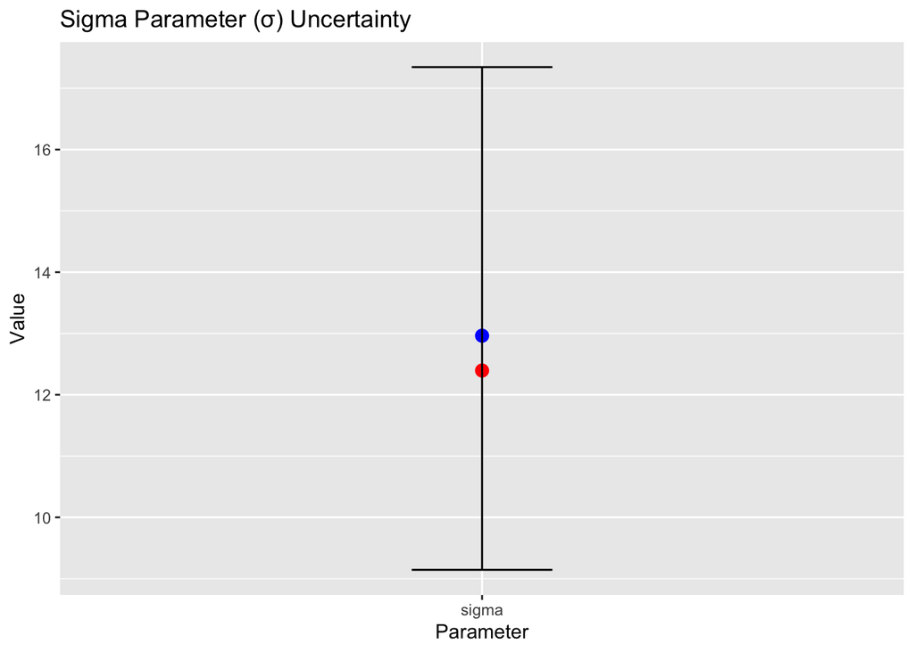

```r
# Plot Parameters
comparison_table %>%
  filter(Parameter == "sigma") %>%
  ggplot(aes(x = Parameter)) +
  geom_point(aes(y = Frequentist), color = "red", size = 3) +
  geom_point(aes(y = Bayesian_Mean), color = "blue", size = 3) +
  geom_errorbar(aes(ymin = CI_5, ymax = CI_95), width = 0.2) +
  labs(
    title = "Sigma Parameter (σ) Uncertainty",
    y = "Value"
  )
```

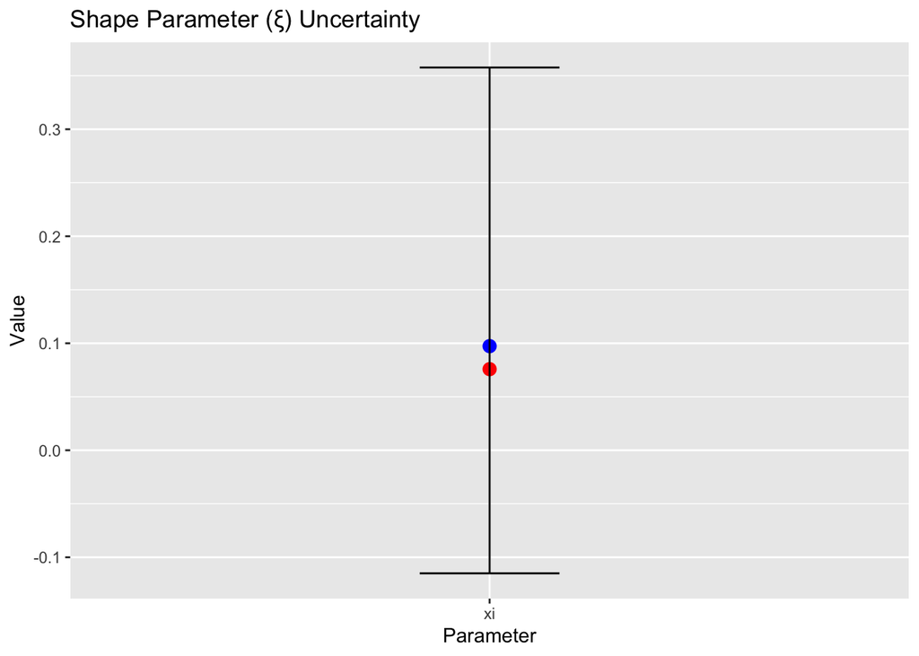

```r
comparison_table %>%
  filter(Parameter == "xi") %>%
  ggplot(aes(x = Parameter)) +
  geom_point(aes(y = Frequentist), color = "red", size = 3) +
  geom_point(aes(y = Bayesian_Mean), color = "blue", size = 3) +
  geom_errorbar(aes(ymin = CI_5, ymax = CI_95), width = 0.2) +
  labs(
    title = "Shape Parameter (ξ) Uncertainty",
    y = "Value"
  )
```

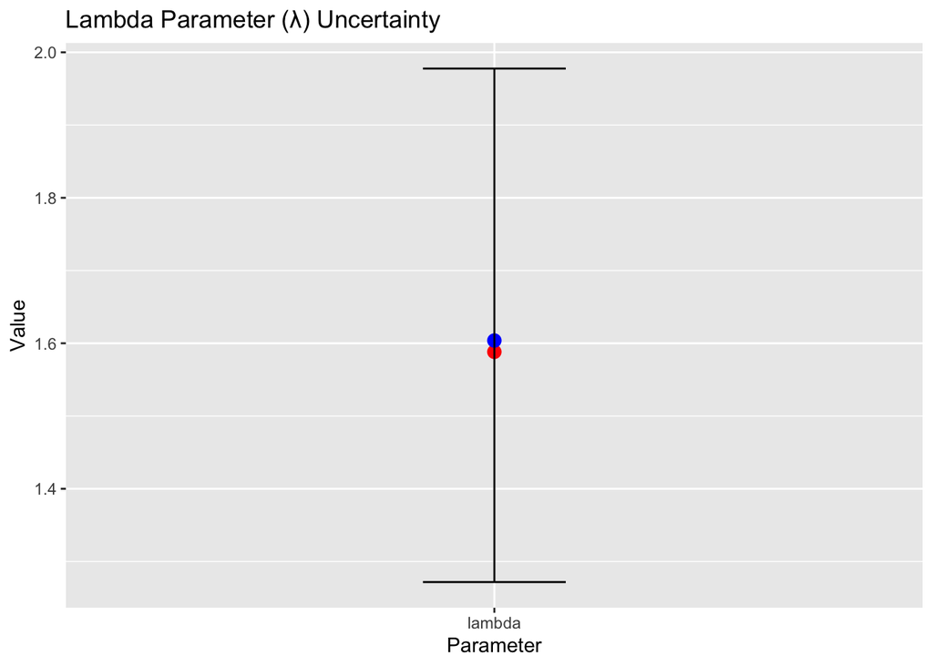

```r
comparison_table %>%
  filter(Parameter == "lambda") %>%
  ggplot(aes(x = Parameter)) +
  geom_point(aes(y = Frequentist), color = "red", size = 3) +
  geom_point(aes(y = Bayesian_Mean), color = "blue", size = 3) +
  geom_errorbar(aes(ymin = CI_5, ymax = CI_95), width = 0.2) +
  labs(
    title = "Lambda Parameter (λ) Uncertainty",
    y = "Value"
  )
```

# Summary

This plot compares frequentist point estimates (red) with Bayesian posterior means (blue), along with 90% credible intervals.

The close alignment between frequentist and Bayesian estimates across all parameters indicates that both approaches are capturing the same underlying structure in the data. This provides a strong consistency check on the model specification.

However, the Bayesian framework reveals an important distinction: parameter uncertainty is not uniform across the model.

- λ (frequency) is tightly constrained, with a narrow credible interval, indicating that event frequency is well-identified.
- σ (scale) shows moderate uncertainty, reflecting natural variability in exceedance magnitudes.
- ξ (shape) exhibits substantial uncertainty, with credible intervals being [-0.11, 0.36].

This behavior of ξ is particularly important. While the point estimate suggests a mildly heavy-tailed distribution, the wide credible interval indicates that tail behavior is weakly identified by the available data.

In practical terms, this means that extreme flood risk estimates are highly sensitive to uncertainty in ξ. Small changes in this parameter can lead to large differences in predicted tail outcomes.

This highlights the key limitation of the frequentist approach: it provides a single point estimate for ξ without quantifying how uncertain that estimate is.

In contrast, the Bayesian framework explicitly captures this uncertainty, making it possible to propagate it into downstream risk metrics such as Annual Exceedance Probability (AEP) curves.